# Elementi *minimali* di programmazione Python

Utili per comprendere il materiale delle esercitazioni che consistono essenzialmente in calcoli eseguiti nell'ambiente Python

Tipi di istruzioni Python, *grammatica* e *sintassi*:

- istruzioni di *assegnazione*;
- istruzioni *condizionali*;
- esecuzione di *cicli*.

### Assegnazioni

Si tratta di assegnare *valori* a *variabili*; i valori possono essere:

- numeri interi;
- numeri decimali;
- caratteri (o *stringhe*: sequenze di caratteri);
- liste (di interi, decimali, stringhe o altre liste).

```python
a = 2  # assegnazione alla variabile a
b = 3  # assegnazione alla variabile b
c=a+b  # somma dei valori contenuti nelle due variabili a e b,
       # con risultato assegnato alla variabile c
print("%i + %i = %i" % (a, b, c))  # Stampa del risultato con una istruzione di print
                                   # formattato
```

```
2 + 3 = 5
```

Assegnazione di variabili *carattere* e somma di *caratteri*

```python
a='1'
b='2'

c=a+b
print("Somma delle stringhe %s e %s = %s" % (a, b, c))
```

```
Somma delle stringhe 1 e 2 = 12
```

Riassegnazioni

```python
a=1       # assegnazione del valore 1 alla variabile a
a=a+1     # riassegnazione ad a del valore a+1
print(a)
```

```
2
```

### Liste

```python
a=[1,2,3,4,5]  # assegnazione di una lista alla variabile a

a_size=len(a)  # numero di elementi della lista
print("Lunghezza della lista: %i" % a_size)
```

```
Lunghezza della lista: 5
```

Gli elementi della lista *a* sono accessibili attraverso il numero intero che rappresenta la loro posizione all'interno della lista, a partire dal numero 0 (*indice* del primo elemento della lista)

`a[j]`

identifica l'elemento di indice *j* nella lista *a*

```python
print("Elementi della lista:")
print(a[0], a[1], a[2], a[3], a[4])
```

```
Elementi della lista:
1 2 3 4 5
```

#### Liste speciali

```python
a_list=range(10)     # definizione di un generatore della lista dei dieci numeri interi
                     # compresi tra 0 e 9
a_list=list(a_list)  # riassegnazione della variabile a_list con la lista effettivamente
                     # generata dal generatore precedente (a_list)
print(a_list)        # stampa della lista
```

```
[0, 1, 2, 3, 4, 5, 6, 7, 8, 9]
```

#### Slicing

Selezione di elementi di una lista

```python
a_list=list(range(10,20))   # generazione di una lista di interi da 10 a 19

b_list=a_list[2:8]          # selezione degli elementi della lista, dalla posizione 2 alla 7
c_list=a_list[::2]          # selezione degli elementi dalla prima posizione all'ultima,
                            # con 'passo' 2
d_list=a_list[1::2]         # selezione degli elementi dalla posizione 1 (secondo
                            # elemento della lista) fino all'ultimo, con passo 2

print("a_list: ", a_list)
print("b_list: ", b_list)
print("c_list: ", c_list)
print("d_list: ", d_list)
```

```
a_list:  [10, 11, 12, 13, 14, 15, 16, 17, 18, 19]
b_list:  [12, 13, 14, 15, 16, 17]
c_list:  [10, 12, 14, 16, 18]
d_list:  [11, 13, 15, 17, 19]
```

#### Libreria *numpy* e *array*

```python
import numpy as np             # importazione della libreria numpy (con alias np)

x_list=np.linspace(-1, 1, 10)  # creazione di un array di 10 numeri decimali compresi tra -1 e 1

print(x_list)                  # stampa dell'array
```

```
[-1.         -0.77777778 -0.55555556 -0.33333333 -0.11111111  0.11111111
  0.33333333  0.55555556  0.77777778  1.        ]
```

#### Uso degli array nella costuzione del grafico di una funzione

Si vuole di seguito tracciare il grafico della funzione

$$y = x^3 - 0.5x^2 -x +2$$

nell'intervallo [-1, 1] (funzione calcolata in 100 punti).

Ottenuti gli array *x_list* e *y_list*, si usano le funzioni della libreria grafica *matplotlib.pyplot* per effettuare il grafico

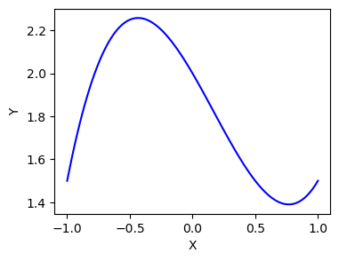

```python
import matplotlib.pyplot as plt

x_list=np.linspace(-1,1,100)
y_list=x_list**3 - 0.5*x_list**2 - x_list + 2

plt.figure(figsize=(4,3))
plt.plot(x_list, y_list, "b-")
plt.xlabel("X")
plt.ylabel("Y")
plt.show()
```

### Istruzioni condizionali

Costrutto `IF/ELIF/ELSE`

```
if test_1:
   se test_1 è superato, esegui istruzione_1
elif test_2:
   se test_1 non è superato e test_2 è superato, esegui istruzione_2
else:
   se test_1 e test_2 non sono superati, esegui istruzione_3
```

*test_1*, *test_2* e *test_3* sono variabili *booleane* che possono assumere solo i due valori *vero* (*True*) e *falso* (*False*)

```python
a = 1

if a > 2:
    print("Il valore di a è maggiore di 2")
elif a == 2:
    print("Il valore di a è uguale a 2")
else:
    print("Il valore di a è minore di 2")
```

```
Il valore di a è minore di 2
```

Nella cella sopra si confronta per esempio il valore di *a* (assegnato a 1) con il numero 2, per cui è falso che `a > 2`

```python
test_1 = a > 2
print("test_1: ", test_1)
```

```
test_1:  False
```

La presenza di `elif` e `else` è opzionale

### Cicli

Esecuzione di una o più operazioni, ripetute più volte, all'interno di un *ciclo*.

```
for iv in v_list:
    esegui istruzione
```

dove *iv* è la variabile del ciclo che assume, ad ogni ciclo, i diversi valori contenuti nella lista *v_list*.

```python
a_list=[10,20,30,40]

for ia in a_list:
    ib=ia*2
    print("%i * 2 = %i"  % (ia, ib))
```

```
10 * 2 = 20
20 * 2 = 40
30 * 2 = 60
40 * 2 = 80
```

Alternativamente al costrutto precedente, si possono usare gli indici degli elementi della lista *a_list*:

```python
a_size=len(a_list)

for ia in range(a_size):
    ib=a_list[ia]*2
    print("%i)   %i * 2 = %i"  % (ia+1, a_list[ia], ib))
```

```
1)   10 * 2 = 20
2)   20 * 2 = 40
3)   30 * 2 = 60
4)   40 * 2 = 80
```

Esempio: estrazione dei multipli di 4 nell'intervallo 1-40

```python
num=4                            # numero scelto (4)
a_list=list(range(1, num*10+1))  # generazione di una lista di interi (tra 1 e 40)

b_list=[]                        # inizializzazione di una lista vuota (b_list)

for ia in a_list:                # ciclo su tutti gli elementi di a_list
    if ia%num == 0:              # resto della divisione per 4: se zero allora
       b_list.append(ia)         # metti il numero nella lista b_list

print(b_list)
```

```
[4, 8, 12, 16, 20, 24, 28, 32, 36, 40]
```

## Funzioni

Definizione di *funzioni* per calcoli specifici.

```
def nome_funzione(argomento/i funzione):
    corpo della funzione
    restituzione di un risultato
```

```python
# Definizione della funzione 'square' che
# restituisce il quadrato di un numero.
#
# L'argomento della funzione è rappresentato dalla
# variabile x; la variabile y è il quadrato di x.
#
# Il valore y calcolato dalla funzione è 'restituito'
# attraverso l'istruzione di 'return'

def square(x):
    y = x**2
    return y
```

Esempio di uso della funzione:

```python
a_list = [1,2,3,4,5]

for ia in a_list:
    ib=square(ia)
    print("%i^2 = %i" % (ia, ib))
```

```
1^2 = 1
2^2 = 4
3^2 = 9
4^2 = 16
5^2 = 25
```

Grafico della funzione

$$y = 10\cdot e^{(-x/10)}\cdot \cos(x)$$

per $x$ che varia tra 0 e $10\pi$, realizzato attraverso le funzioni *fun*, *plot* e *make_plot*

```python
def fun(x, fact, amplitude):
    y=amplitude*np.exp(-1*fact*x)*np.cos(x)
    return y

def plot(x,y):
    plt.figure(figsize=(5,3))
    plt.plot(x,y)
    plt.xlabel("X")
    plt.ylabel("Y")
    plt.show()

def make_plot(xmin, xmax, fact=0.1, amplitude=10., npoint=500):
    x_list=np.linspace(xmin, xmax, npoint)
    y_list=fun(x_list, fact, amplitude)
    plot(x_list, y_list)
```

Uso della funzione *make_plot*

Chiamiamo la funzione con argomenti 0, $10\pi$, non specificando il numero di punti (*npoint*) nell'intervallo (risoluzione del grafico), il che vuol dire che si accetta il valore di *default* previsto per questo parametro *opzionale* (500). Lo stesso vale per i due parametri *fact* e *amplitude* che sono lasciati ai loro valori di default.

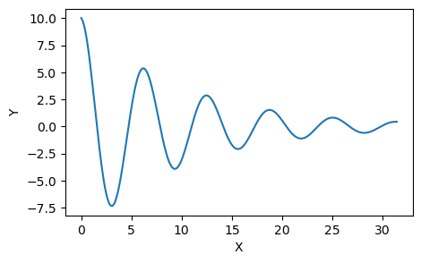

```python
make_plot(0, 10*np.pi)
```